# NTU PS0002 Lab 2

Benjamin benjamin.koh@ntu.edu.sg

Before we begin, here’s a brief recap of Lab 1.

```r
# this is not an exhaustive list
getwd() # find where your working directory is
setwd("~/Documents/ps2") # to change your working directory to Documents/ps2
# folder needs to be created prior to changing the directory
# convenient locations Desktop/ps2 or  Downloads/ps2 or Documents/ps2
read.table() # for reading txt files
read.fwf() # if data files are in a fixed width format
read.csv() # for files in csv format

# import data by changing filename in the line below (file has to be in working directory for the code to run properly)
# else, you have to indicate the complete file path
# e.g.
dat1<-read.table("ex1.3.txt")

c() # to combine different objects together in a vector
# use <- for assignment of variables

# techniques that you should know
# use of vector1[n] to refer to nth element in a vector
# use of dataframe1[a, ] to filter specific rows in a data frame
# use of dataframe1[,b] to filter specific columns in a data frame
# use of attach(dataframe1) to refer to variables directly
# alternatively, use dataframe$variable to directly refer to specific variables

# other concepts innclude the use of subset() to perform filtering
# sorting data frames, merging data frames
```

By the end of lab 2, you should know the following:

1. install and load libraries/packages in R
2. usage of `dplyr` library

## 1) Install and load libraries in R

In R, libraries (also called packages) are collections of pre-written code that extend the functionality of the base R language. They contain functions, datasets, and documentation that you can use to simplify your tasks, enhance your analyses, or add new capabilities to R. (similar to modules in Python)

There are two main functions to grasp here.

Note: You do not have to repeatedly install a library. Once you have downloaded a library, it will be accessible to you the next time you launch R, provided that you **load** the library.

**Note** When installing a library, you need to put wrap the library name in quotations.

```r
# note: if library not installed yet, you will receive an error
# when you run the following line without the hash
# library("nycflights13")

# to install a library
install.packages('nycflights13')

# to load a library
library('nycflights13')


# following line allows us to install and load a library (nycflights13) if it's not on R
# if library is in R, it will load the library immediately
if (!require('nycflights13')) install.packages('nycflights13'); library('nycflights13')
```

### Brief discussion on nycflights13

`nycflights13` is a library consisting of 5 different data frames. It provides information about flights departing from New York City (NYC) airports in 2013.

To explore the contents in a library, you will need to load the library first.

Then, you can try typing `libraryname::` **on your console** e.g. `nycflights13::`

```r
library(nycflights13) # after installing a package,
# we need to load it into R in order to use it.

# nycflights13 is a library which contains many data frames
# To see the list of data frames in nycflights13,
# in the R console, type nycflights13::

# print(variable) allows us to see what's inside a variable/data frame
# print will print everything onto the console
# we can include the option n = .. to restrict the amount of lines printed
print(flights,n=5) # to view up till 5th row

# alternative ways to view flights
nycflights13::flights

# we can refer to the data frames in the nycflights13 library after loading it
# after loading the library, flights and other data frames in nycflights13 have not been assigned as a variable. (Not observed under the environment tab).
# howeer, we can still access flights and use the name in our codes
# without any error being produced
head(flights)
```

Personally, I prefer to store data frames in the library as a variable so I can view it in the Environment panel.

```r
flights<-flights # to store in a variable to view
```

## 2) Intro to dplyr

`dplyr` is a library that provides a set of functions for data manipulation. It is part of a collection of R packages designed for data science.

Common data manipulation operations include:

1. `select` - select columns/variables
2. `filter` - select rows/observations
3. `mutate` - add columns/variables
4. `arrange` - re-order observations
5. `summarise` - reduce info to a single row
6. `group_by` - aggregate different
7. `left_join` - merge different data objects
8. `distinct` - remove duplicate entries

There are two ways to use dplyr.

1. Using the Pipe Operator (`%>%`):

   The pipe operator (`%>%`) is a core features of dplyr, and it allows us to chain multiple operations together in a **left-to-right sequence**. This makes the code more readable by eliminating the need for nested functions and ensuring that each operation is performed step-by-step.

   Example: `new_data <- data %>% verb1(options) %>% verb2(options) %>% verb3(options)`

   How it works: The pipe operator takes the output of the expression on its left and “pipes” it into the next function on its right. Each verb (`verb1, verb2, verb3`, etc.) is applied sequentially to the data.
2. Using Each Verb as a Function:

   Alternatively, you can use each dplyr verb as a standalone function, one after the other. In this case, you’ll typically nest the functions. Just like in mathematics, when dealing with composite functions, R processes the innermost function first.

   Example: `new_data <- verb3(verb2(verb1(data, options1), options2), options3)`

   How it works: The operations are nested inside each other. R will first evaluate the innermost function (`verb1()`), then apply `verb2()` to the result, and then finally apply `verb3()` to the outcome.

### Template for dplyr verbs

```r
# to install and load dplyr
if (!require('dplyr')) install.packages('dplyr'); library('dplyr')

# method 1: Chaining operations with %>%
'new_data <- data %>%
  verb1(options) %>%     # First verb/operation
  verb2(options) %>%     # Second verb/operation
  verb3(options)         # Third verb/operation
'

# method 2: Using verbs as nested functions
' new_data <- verb3(verb2(verb1(data, options1), options2), options3)
'
```

### Selecting specific columns

`select()` allows us to choose specific columns from a data frame

```r
library(dplyr)
library(nycflights13)
airports<-airports
flights<-flights

# when using dplyr, we can refer to the column names freely, without
# using attach() from base R.

# select() – Select Columns/Variables
# to choose specific columns or variables from a data frame or tibble.

# Example:
# Select faa and name columns from the airportdata
# using pipe operator
df <- flights %>% select(1:3, dep_delay,arr_delay,carrier)

# using verbs as a function
df_verb<-select(flights,1:3, dep_delay,arr_delay,carrier)
head(df_verb,n=3)
```

```
## # A tibble: 3 × 6
##    year month   day dep_delay arr_delay carrier
##   <int> <int> <int>     <dbl>     <dbl> <chr>
## 1  2013     1     1         2        11 UA
## 2  2013     1     1         4        20 UA
## 3  2013     1     1         2        33 AA
```

### Additional options for select()

We can include the following options in `select()` to allow us to select specific columns.

- `starts_with()`: Select columns that start with a character string
- `ends_with()`: Select columns that end with a character string
- `contains()`: Select columns that contain a character string
- `matches()`: Select columns that match a regular expression

```r
library(nycflights13)
flights<-flights
df <- flights %>% select(1:3, dep_delay,arr_delay,carrier)

# starts_with
df_select_d<-df%>% select(starts_with("d"))

# ends_with
df_select_delay<-df%>% select(ends_with("delay"))

# contains
df_contain_delay<-df%>% select(contains("delay"))

# matches
df_matches_day<-df%>% select(matches("day"))

# more examples
df_contain_delay<-df%>% select(day,contains("delay"),starts_with("carrier"))

# we can use matches() to select multiple columns
# here, I am selecting columns that have either "dep" or "arr" in the column name.
df_contain_delay<-df%>% select(matches("dep|arr"))
```

### Additional concept to to omit a few columns instead of just omitting one column

```r
# we can use column number or column name when selecting

# omit consecutive columns
dfomitted1<-df%>% select(-(year:day))
dfomitted2<-df%>% select(-(1:3))
head(dfomitted1,n=3)
```

```
## # A tibble: 3 × 3
##   dep_delay arr_delay carrier
##       <dbl>     <dbl> <chr>
## 1         2        11 UA
## 2         4        20 UA
## 3         2        33 AA
```

```r
head(dfomitted2,n=3)
```

```
## # A tibble: 3 × 3
##   dep_delay arr_delay carrier
##       <dbl>     <dbl> <chr>
## 1         2        11 UA
## 2         4        20 UA
## 3         2        33 AA
```

```r
# omit multiple columns (not side-by-side)
dfomitted3<-df%>% select(-c(1,3))
dfomitted4<-df%>% select(-c(year,day))
head(dfomitted3,n=3)
```

```
## # A tibble: 3 × 4
##   month dep_delay arr_delay carrier
##   <int>     <dbl>     <dbl> <chr>
## 1     1         2        11 UA
## 2     1         4        20 UA
## 3     1         2        33 AA
```

```r
head(dfomitted4,n=3)
```

```
## # A tibble: 3 × 4
##   month dep_delay arr_delay carrier
##   <int>     <dbl>     <dbl> <chr>
## 1     1         2        11 UA
## 2     1         4        20 UA
## 3     1         2        33 AA
```

### Filtering

`filter()` allows us to filter rows based on conditions. We are able to filter numerical and categorical data.

```r
# filter() – Select Rows/Observations
# to filter rows based on conditions

# Example:
# Filter rows where dep_delay is greater than 0
# using pipe operator
df_filtered <- df %>% filter(dep_delay > 0)

# using verbs as a function
df_filtered_verb<-filter(df,dep_delay > 0)

head(df_filtered,n=3)
```

```
## # A tibble: 3 × 6
##    year month   day dep_delay arr_delay carrier
##   <int> <int> <int>     <dbl>     <dbl> <chr>
## 1  2013     1     1         2        11 UA
## 2  2013     1     1         4        20 UA
## 3  2013     1     1         2        33 AA
```

```r
# Further example where we are filtering a categorical variable/column
# filtering rows with faa values ALB, BDL and BTV
# ALB, BDL and BTV are texts/strings. so we need quotations.
# c() is a function to concatenate them together

# using pipe operator
airports_filtered_pipe<-airports %>% filter(faa %in% c('ALB','BDL','BTV'))

# using verbs as a function
airports_filtered_verb<-airports %>% filter(faa %in% c('ALB','BDL','BTV'))
head(airports_filtered_verb,n=3)
```

```
## # A tibble: 3 × 8
##   faa   name              lat   lon   alt    tz dst   tzone
##   <chr> <chr>           <dbl> <dbl> <dbl> <dbl> <chr> <chr>
## 1 ALB   Albany Intl      42.7 -73.8   285    -5 A     America/New_York
## 2 BDL   Bradley Intl     41.9 -72.7   173    -5 A     America/New_York
## 3 BTV   Burlington Intl  44.5 -73.2   335    -5 A     America/New_York
```

**Note: Usage of %in%**

When checking if a particular phrase is in a vector, the syntax to use is `phrase %in% vector`, not `vector %in% phrase`.

When we are filtering rows that contain a specific term, the syntax is `df %>% filter(column %in% specific terms)`, not `df %>% filter(specific terms %in% column)`

### Mutating (Transforming columns)

`mutate()` allows us to create new columns or modify existing columns

```r
# mutate() – Add Columns/Variables
# to create new columns or modify existing ones.

# Example:
# Calculate total delay
# using pipe operator
df_filtered <- df_filtered %>% mutate(total_delay = dep_delay+arr_delay)
# using verbs as a function
df_filtered_verb<-mutate(df_filtered,total_delay = dep_delay+arr_delay)

head(df_filtered,n=3)
```

```
## # A tibble: 3 × 7
##    year month   day dep_delay arr_delay carrier total_delay
##   <int> <int> <int>     <dbl>     <dbl> <chr>         <dbl>
## 1  2013     1     1         2        11 UA               13
## 2  2013     1     1         4        20 UA               24
## 3  2013     1     1         2        33 AA               35
```

### Arranging

`arrange()` allows us to sort data frame according to specified columns. The default sorts in ascending order. To sort in descending order, include `desc()`.

```r
# arrange() – Re-order Observations
# to reorder rows based on one or more variables.
# By default, it sorts in ascending order,
# but you can use the desc() function for descending order.

# Example:
# Arrange rows by tot_delay in descending order
# using pipe operator
df_filtered <- df_filtered %>% arrange(desc(total_delay))
# using verbs as a function
df_filtered_verb <-arrange(df_filtered,desc(total_delay))

head(df_filtered,n=3)
```

```
## # A tibble: 3 × 7
##    year month   day dep_delay arr_delay carrier total_delay
##   <int> <int> <int>     <dbl>     <dbl> <chr>         <dbl>
## 1  2013     1     9      1301      1272 HA             2573
## 2  2013     6    15      1137      1127 MQ             2264
## 3  2013     1    10      1126      1109 MQ             2235
```

```r
# Example:
# Arrange rows by arr_delay, followed by dep_delay
df_filtered <- df_filtered %>% arrange(arr_delay,dep_delay)
# using verbs as a function
df_filtered_verb <-arrange(df_filtered,arr_delay,dep_delay)

head(df_filtered,n=3)
```

```
## # A tibble: 3 × 7
##    year month   day dep_delay arr_delay carrier total_delay
##   <int> <int> <int>     <dbl>     <dbl> <chr>         <dbl>
## 1  2013     3     1         1       -65 DL              -64
## 2  2013     5     4         3       -63 UA              -60
## 3  2013    11    13         9       -63 DL              -54
```

### Summarising

`summarise()` allows us to calculate descriptive statistics.

```r
# summarise() or summarize() – Reduce Info to a Single Row
# to calculate summary statistics, such as the mean, sum, count, etc.,
# over one or more variables.
# often pair with group_by() to calculate statistics by group.

# Example:
# Calculate average dep_delay and total_delay
# using pipe operator
df_summary <- df_filtered %>%
  summarise(mean_dep_delay = mean(dep_delay),
            mean_total_delay = mean(total_delay, na.rm = TRUE))
# na.rm = TRUE instructs R to ignore any missing values marked as NA when
# calculating

# using verbs as a function
df_summary_verb <- summarise(df_filtered,mean_dep_delay = mean(dep_delay),
            mean_total_delay = mean(total_delay, na.rm = TRUE))

head(df_summary,n=3)
```

```
## # A tibble: 1 × 2
##   mean_dep_delay mean_total_delay
##            <dbl>            <dbl>
## 1           39.4             73.9
```

```r
# fyi
# following two are the same commands, british or american spelling for summarise
flights %>% filter(dest == 'ORD') %>% summarize(mean_dep_delay = mean(dep_delay)) # obtain number of flights with destination at ORD
```

```
## # A tibble: 1 × 1
##   mean_dep_delay
##            <dbl>
## 1             NA
```

```r
flights %>% filter(dest == 'ORD') %>% summarise(mean_dep_delay = mean(dep_delay))
```

```
## # A tibble: 1 × 1
##   mean_dep_delay
##            <dbl>
## 1             NA
```

### Additional examples using `summarise()`

```r
# useful functions within summarise
# Mean (Average): Calculate the mean (average) value for a numeric column.
df%>% summarise(mean_value = mean(dep_delay,na.rm=TRUE))

# Sum: Calculate the sum of a numeric column.
df%>%summarise(total_dep_delay = sum(dep_delay,na.rm=TRUE))

# Median: Find the median value for a numeric column.
df%>% summarise(median_value = median(dep_delay,na.rm=TRUE))

# Standard Deviation: Calculate the standard deviation of a numeric column.
df%>%summarise(sd_value = sd(dep_delay,na.rm=TRUE))

# Variance: Calculate the variance of a numeric column.
df%>%summarise(sd_value = var(dep_delay,na.rm=TRUE))

# Minimum and Maximum: Find the minimum and maximum values of a column.
df%>%summarise(min_value = min(dep_delay,na.rm=TRUE),max_value = max(dep_delay,na.rm=TRUE))

# Quantiles: Calculate specific quantiles, like the 25th and 75th percentiles.
df%>%summarise(Q1 = quantile(dep_delay,0.25,na.rm=TRUE))

# Count: Count the number of records in each group.
df%>%summarise(count =n())

# there are other items that you can retrieve with summarise,
# such as number of unique values, proportions,  etc.
# explore dplyr documentation for more info.
```

### Grouping

`group_by()` is often paired with `summarise()` in order for us to aggregate data and calculate values for each group.

Message printed on console: `summarise() has grouped output by columnname You can override using the .groups argument`.

This message helps to make the user aware that a grouping was performed using `columnname` . However, the message does not have an impact on the final result. It is just a friendly warning message that can usually be ignored.

Also, when using multiple columns to group our data, `dplyr` drops the last group variable that was specified in the `group_by` function when printing the message.

```r
# group_by() – Aggregate by Groups
# to split data into groups based on one or more variables.
# After grouping, you can apply summary functions like summarise()
# or mutate() to each group.

# Example:
# Group data by carrier and then
# calculate average dep_delay and total_delay
# using pipe operator
df_group_summary <- df_filtered %>% group_by(carrier)%>%
  summarise(mean_dep_delay = mean(dep_delay),
            mean_total_delay = mean(total_delay, na.rm = TRUE))

# using verbs as a function
# using dplyr functions as bested functions decreases
# the readability of your code

df_group_summary_verb<-summarise(group_by(df_filtered,carrier),
                                 mean_dep_delay = mean(dep_delay),
                                 mean_total_delay = mean(total_delay,
                                                         na.rm = TRUE))
head(df_group_summary,n=3)
```

```
## # A tibble: 3 × 3
##   carrier mean_dep_delay mean_total_delay
##   <chr>            <dbl>            <dbl>
## 1 9E                48.9             88.8
## 2 AA                37.2             67.6
## 3 AS                31.3             48.9
```

```r
######### fyi: to compare the effects of using group_by()
flights_ungrouped<-flights
# grouping by carrier
flights_ungrouped_bycarrier <- flights %>% group_by(carrier)

head(flights_ungrouped,n=3)
```

```
## # A tibble: 3 × 19
##    year month   day dep_time sched_dep_time dep_delay arr_time sched_arr_time
##   <int> <int> <int>    <int>          <int>     <dbl>    <int>          <int>
## 1  2013     1     1      517            515         2      830            819
## 2  2013     1     1      533            529         4      850            830
## 3  2013     1     1      542            540         2      923            850
## # ℹ 11 more variables: arr_delay <dbl>, carrier <chr>, flight <int>,
## #   tailnum <chr>, origin <chr>, dest <chr>, air_time <dbl>, distance <dbl>,
## #   hour <dbl>, minute <dbl>, time_hour <dttm>
```

```r
head(flights_ungrouped_bycarrier,n=3)
```

```
## # A tibble: 3 × 19
## # Groups:   carrier [2]
##    year month   day dep_time sched_dep_time dep_delay arr_time sched_arr_time
##   <int> <int> <int>    <int>          <int>     <dbl>    <int>          <int>
## 1  2013     1     1      517            515         2      830            819
## 2  2013     1     1      533            529         4      850            830
## 3  2013     1     1      542            540         2      923            850
## # ℹ 11 more variables: arr_delay <dbl>, carrier <chr>, flight <int>,
## #   tailnum <chr>, origin <chr>, dest <chr>, air_time <dbl>, distance <dbl>,
## #   hour <dbl>, minute <dbl>, time_hour <dttm>
```

```r
# on the surface, flights_ungrouped appears same as bycarrier
# however, when we try to perform some operations, we can compare outputs to observe (any) differences
flights_ungrouped_bycarrier %>% summarise(mean_dep_delay = mean(dep_delay,na.rm=TRUE))
```

```
## # A tibble: 16 × 2
##    carrier mean_dep_delay
##    <chr>            <dbl>
##  1 9E               16.7
##  2 AA                8.59
##  3 AS                5.80
##  4 B6               13.0
##  5 DL                9.26
##  6 EV               20.0
##  7 F9               20.2
##  8 FL               18.7
##  9 HA                4.90
## 10 MQ               10.6
## 11 OO               12.6
## 12 UA               12.1
## 13 US                3.78
## 14 VX               12.9
## 15 WN               17.7
## 16 YV               19.0
```

```r
flights_ungrouped %>% summarise(mean_dep_delay = mean(dep_delay,na.rm=TRUE))
```

```
## # A tibble: 1 × 1
##   mean_dep_delay
##            <dbl>
## 1           12.6
```

### Joining

`left_join()` and `right_join()` are functions in `dplyr` which allows us to join data frames together. `left_join(df1,df2 )` keeps all rows from df1 in the merged data frame while `right_join(df1,df2)` keeps all rows from df2 in the merged data frame.

```r
# left_join() – Merge Data Objects
# merges two data frames (or tibbles) by a common column,
# keeping all rows from the left data frame
# and matching rows from the right data frame.

# Example:
planes<-nycflights13::planes
df_left<-planes%>%select(tailnum,type,year)
df_right<-planes%>%select(tailnum,model,manufacturer)
# the common column needs to have unique values, else there will be complications
# using pipe operator
df_joined <- df_left %>% left_join(df_right, by = "tailnum")
# using verbs as a function
df_joined_verb <- left_join(df_left,df_right, by = "tailnum")

head(df_joined,n=3)
```

```
## # A tibble: 3 × 5
##   tailnum type                     year model     manufacturer
##   <chr>   <chr>                   <int> <chr>     <chr>
## 1 N10156  Fixed wing multi engine  2004 EMB-145XR EMBRAER
## 2 N102UW  Fixed wing multi engine  1998 A320-214  AIRBUS INDUSTRIE
## 3 N103US  Fixed wing multi engine  1999 A320-214  AIRBUS INDUSTRIE
```

### Additional functions in dplyr (optional)

```r
# distinct() – Remove Duplicate Entries
# to return only unique rows or values,
# removing duplicates based on one or more columns.

# Example:
# Find distinct carrier
# using pipe operator
df_distinct <- df_filtered %>% distinct(carrier)
# using verbs as a function
df_distinct_verb <- distinct(df_filtered,carrier)

head(df_distinct_verb,n=3)
```

```
## # A tibble: 3 × 1
##   carrier
##   <chr>
## 1 DL
## 2 UA
## 3 HA
```

```r
# Example:
# Find distinct day - month combinations
# using pipe operator
df_distinct_daymonths <- df_filtered %>% distinct(day,month)
# using verbs as a function
df_distinct_daymonths_verb <-distinct(df_filtered,day,month)
head(df_distinct_daymonths,n=3)
```

```
## # A tibble: 3 × 2
##     day month
##   <int> <int>
## 1     1     3
## 2     4     5
## 3    13    11
```

```r
# ix) rename() – Rename Columns/Variables
# to rename one or more columns in a data frame.

# Example:
# Rename type as engine, tailnum as planeid in df_joined
# using pipe operator
df_renamed <- df_joined %>% rename(engine = type,planeid=tailnum)
# using verbs as a function
df_renamed_verb <- rename(df_joined,engine = type,planeid=tailnum)
```

### Test your understanding

Go through each of the examples to test your understanding of the functions and their usage. Try to work out what the output looks like before checking the result.

```r
# Example 1
example1 <- flights %>%
  group_by(dest) %>%
  filter(dest %in% c('ALB','BDL','BTV')) %>%
  summarise(numflights = n())

# Answer: grouping by dest first, before filtering for specific destinations
# followed by summarising number of flights to the specific destinations
example1
```

```
## # A tibble: 3 × 2
##   dest  numflights
##   <chr>      <int>
## 1 ALB          439
## 2 BDL          443
## 3 BTV         2589
```

```r
# Example 2
example2 <- flights %>%
  filter(dest %in% c('ALB','BDL','BTV')) %>%
  group_by(year, month) %>%
  summarise(numflights = n())
# Answer: filtering by dest for specific destinations
# followed by grouping by year & month, then summarise number of flights
example2
```

```
## # A tibble: 12 × 3
## # Groups:   year [1]
##     year month numflights
##    <int> <int>      <int>
##  1  2013     1        324
##  2  2013     2        293
##  3  2013     3        376
##  4  2013     4        297
##  5  2013     5        372
##  6  2013     6        346
##  7  2013     7        253
##  8  2013     8        284
##  9  2013     9        204
## 10  2013    10        248
## 11  2013    11        214
## 12  2013    12        260
```

```r
# Example 3
example3 <- flights %>%
  filter(dest %in% c('ALB','BDL','BTV')) %>%
  group_by(year, month, dest) %>%
  summarise(mean_arr_delay = mean(arr_delay,na.rm=TRUE))
# Answer: filtering by dest for specific destinations
# followed by grouping by year, month,dest, then summarise mean arrival delay
example3
```

```
## # A tibble: 36 × 4
## # Groups:   year, month [12]
##     year month dest  mean_arr_delay
##    <int> <int> <chr>          <dbl>
##  1  2013     1 ALB            35.2
##  2  2013     1 BDL            11.0
##  3  2013     1 BTV             6.67
##  4  2013     2 ALB            17.4
##  5  2013     2 BDL             6.05
##  6  2013     2 BTV            15.5
##  7  2013     3 ALB            17.2
##  8  2013     3 BDL            15.3
##  9  2013     3 BTV            18.1
## 10  2013     4 ALB            18
## # ℹ 26 more rows
```

### Further use

The following are codes found in the lecture videos and slides. It involves additional libraries, `lubridate` and `ggplot2`, which will be discussed in greater detail in upcoming labs.

```r
# to install and load lubridate
if (!require('lubridate')) install.packages('lubridate'); library('lubridate')
# lubridate is a R package that makes dealing with time easier.
# We can use ymd() in lubridate to format dates.

airportdailycounts <- flights %>%
  filter(dest %in% c('ALB','BDL','BTV')) %>%
  group_by(year, month, day, dest) %>%
  summarise(numflights = n()) %>% mutate(date= ymd(paste(year, month, day, sep = "-")))
```

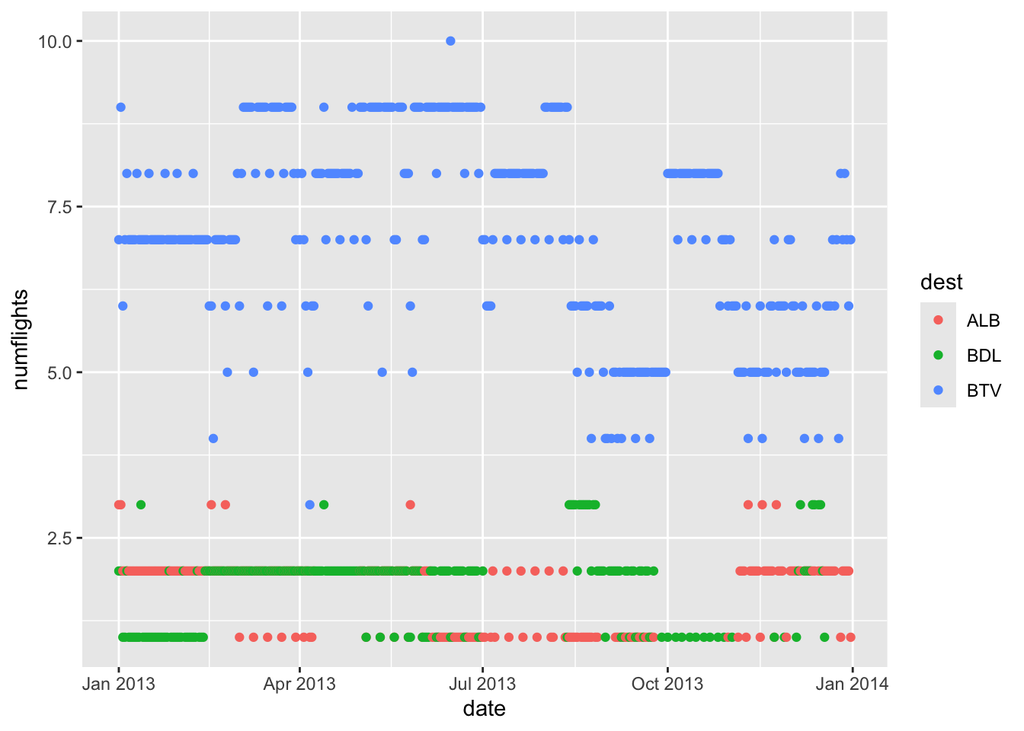

```r
# mutate generates a new column/variable
# here, we use mutate to generate a column called date, and using ymd() from lubridate

# to install and load ggplot2
if (!require('ggplot2')) install.packages('ggplot2'); library('ggplot2')
# plotting number of flights against date, and using separate colours for different destinations
ggplot(data = airportdailycounts, aes(x = date, y = numflights, colour = dest))+ geom_point()
```

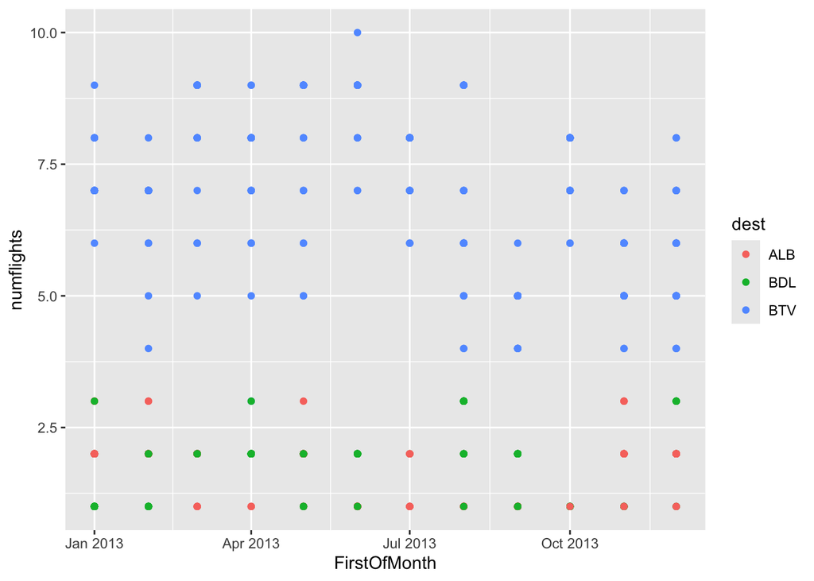

```r
# aes refers to axes.
#geom_point() refers to shape of points. Nothing specified here. circles are default


# creating new variable for date
airportmonthlycounts <- airportdailycounts %>%
  mutate(FirstOfMonth = ymd(paste(year,"-", month, "-01", sep = "")))

ggplot(data=airportmonthlycounts,aes(x=FirstOfMonth, y = numflights, colour = dest)) + geom_point()
```

```r
# sorting by descending order in number of flights
airportmonthlycounts %>% arrange(desc(numflights))
```

```
## # A tibble: 876 × 7
## # Groups:   year, month, day [365]
##     year month   day dest  numflights date       FirstOfMonth
##    <int> <int> <int> <chr>      <int> <date>     <date>
##  1  2013     6    15 BTV           10 2013-06-15 2013-06-01
##  2  2013     1     2 BTV            9 2013-01-02 2013-01-01
##  3  2013     3     4 BTV            9 2013-03-04 2013-03-01
##  4  2013     3     5 BTV            9 2013-03-05 2013-03-01
##  5  2013     3     6 BTV            9 2013-03-06 2013-03-01
##  6  2013     3     7 BTV            9 2013-03-07 2013-03-01
##  7  2013     3     8 BTV            9 2013-03-08 2013-03-01
##  8  2013     3    11 BTV            9 2013-03-11 2013-03-01
##  9  2013     3    12 BTV            9 2013-03-12 2013-03-01
## 10  2013     3    13 BTV            9 2013-03-13 2013-03-01
## # ℹ 866 more rows
```

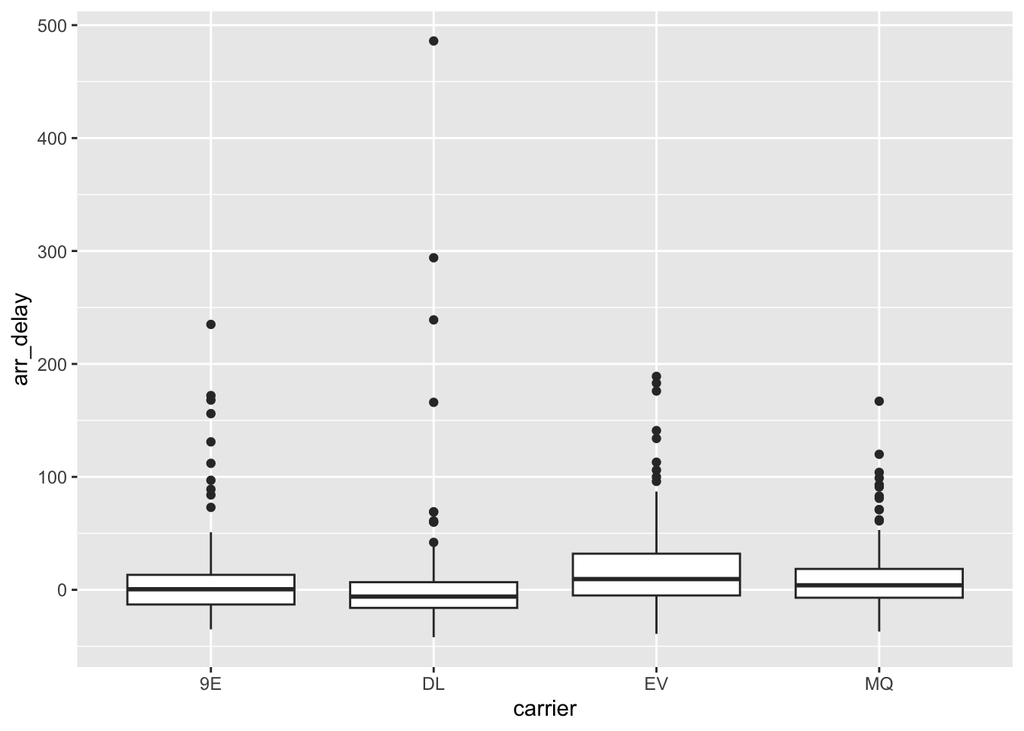

```r
# select() allows us to select specific columns/variables
jandelays <- flights %>% select(origin, dest, year, month, day, carrier, arr_delay) %>%
  filter(dest == 'MSP' & month ==1)
ggplot(data = jandelays, aes(x = carrier, y = arr_delay)) + geom_boxplot()
```

```r
jandelays;airlines # to view these 2 datasets
```

```
## # A tibble: 546 × 7
##    origin dest   year month   day carrier arr_delay
##    <chr>  <chr> <int> <int> <int> <chr>       <dbl>
##  1 LGA    MSP    2013     1     1 DL             -8
##  2 EWR    MSP    2013     1     1 EV             29
##  3 LGA    MSP    2013     1     1 MQ             10
##  4 LGA    MSP    2013     1     1 DL              8
##  5 JFK    MSP    2013     1     1 9E             11
##  6 LGA    MSP    2013     1     1 DL            -10
##  7 LGA    MSP    2013     1     1 DL              3
##  8 LGA    MSP    2013     1     1 MQ             93
##  9 LGA    MSP    2013     1     1 DL             -8
## 10 LGA    MSP    2013     1     1 MQ             91
## # ℹ 536 more rows
```

```
## # A tibble: 16 × 2
##    carrier name
##    <chr>   <chr>
##  1 9E      Endeavor Air Inc.
##  2 AA      American Airlines Inc.
##  3 AS      Alaska Airlines Inc.
##  4 B6      JetBlue Airways
##  5 DL      Delta Air Lines Inc.
##  6 EV      ExpressJet Airlines Inc.
##  7 F9      Frontier Airlines Inc.
##  8 FL      AirTran Airways Corporation
##  9 HA      Hawaiian Airlines Inc.
## 10 MQ      Envoy Air
## 11 OO      SkyWest Airlines Inc.
## 12 UA      United Air Lines Inc.
## 13 US      US Airways Inc.
## 14 VX      Virgin America
## 15 WN      Southwest Airlines Co.
## 16 YV      Mesa Airlines Inc.
```

```r
# merging datasets together
merged <- left_join(jandelays,airlines, by=c("carrier"= "carrier"))
merged
```

```
## # A tibble: 546 × 8
##    origin dest   year month   day carrier arr_delay name
##    <chr>  <chr> <int> <int> <int> <chr>       <dbl> <chr>
##  1 LGA    MSP    2013     1     1 DL             -8 Delta Air Lines Inc.
##  2 EWR    MSP    2013     1     1 EV             29 ExpressJet Airlines Inc.
##  3 LGA    MSP    2013     1     1 MQ             10 Envoy Air
##  4 LGA    MSP    2013     1     1 DL              8 Delta Air Lines Inc.
##  5 JFK    MSP    2013     1     1 9E             11 Endeavor Air Inc.
##  6 LGA    MSP    2013     1     1 DL            -10 Delta Air Lines Inc.
##  7 LGA    MSP    2013     1     1 DL              3 Delta Air Lines Inc.
##  8 LGA    MSP    2013     1     1 MQ             93 Envoy Air
##  9 LGA    MSP    2013     1     1 DL             -8 Delta Air Lines Inc.
## 10 LGA    MSP    2013     1     1 MQ             91 Envoy Air
## # ℹ 536 more rows
```

```r
# check dimensions
dim(merged)
```

```
## [1] 546   8
```

## Lab Tasks

The following tasks focus on the mammals sleep data set

```r
download.file(url<-"https://raw.githubusercontent.com/genomicsclass/dagdata/master/inst/extdata/msleep_ggplot2.csv", destfile = "msleep_ggplot2.csv")
df<-read.csv("msleep_ggplot2.csv")
```

### Task 1 - 3

Please complete the following tasks:

```r
# 1. Check the number of rows and columns using “dim()”

dim(df)
```

```
## [1] 83 11
```

```r
# 2. Show a summary of all variables (columns) in the dataset using “summary()”

summary(df)
```

```
##      name              genus               vore              order
##  Length:83          Length:83          Length:83          Length:83
##  Class :character   Class :character   Class :character   Class :character
##  Mode  :character   Mode  :character   Mode  :character   Mode  :character
##
##
##
##
##  conservation        sleep_total      sleep_rem      sleep_cycle
##  Length:83          Min.   : 1.90   Min.   :0.100   Min.   :0.1167
##  Class :character   1st Qu.: 7.85   1st Qu.:0.900   1st Qu.:0.1833
##  Mode  :character   Median :10.10   Median :1.500   Median :0.3333
##                     Mean   :10.43   Mean   :1.875   Mean   :0.4396
##                     3rd Qu.:13.75   3rd Qu.:2.400   3rd Qu.:0.5792
##                     Max.   :19.90   Max.   :6.600   Max.   :1.5000
##                                     NA's   :22      NA's   :51
##      awake          brainwt            bodywt
##  Min.   : 4.10   Min.   :0.00014   Min.   :   0.005
##  1st Qu.:10.25   1st Qu.:0.00290   1st Qu.:   0.174
##  Median :13.90   Median :0.01240   Median :   1.670
##  Mean   :13.57   Mean   :0.28158   Mean   : 166.136
##  3rd Qu.:16.15   3rd Qu.:0.12550   3rd Qu.:  41.750
##  Max.   :22.10   Max.   :5.71200   Max.   :6654.000
##                  NA's   :27
```

```r
# 3. Show the first 10 rows using function “head()”
head(df)
```

```
##                         name      genus  vore        order conservation
## 1                    Cheetah   Acinonyx carni    Carnivora           lc
## 2                 Owl monkey      Aotus  omni     Primates         <NA>
## 3            Mountain beaver Aplodontia herbi     Rodentia           nt
## 4 Greater short-tailed shrew    Blarina  omni Soricomorpha           lc
## 5                        Cow        Bos herbi Artiodactyla domesticated
## 6           Three-toed sloth   Bradypus herbi       Pilosa         <NA>
##   sleep_total sleep_rem sleep_cycle awake brainwt  bodywt
## 1        12.1        NA          NA  11.9      NA  50.000
## 2        17.0       1.8          NA   7.0 0.01550   0.480
## 3        14.4       2.4          NA   9.6      NA   1.350
## 4        14.9       2.3   0.1333333   9.1 0.00029   0.019
## 5         4.0       0.7   0.6666667  20.0 0.42300 600.000
## 6        14.4       2.2   0.7666667   9.6      NA   3.850
```

### Task 4

Using dplyr verb `select()` - select a set of columns: the “name” and the “sleep_total” columns

- select all the columns except a specific column, use the “-“ (subtraction) operator
- select a range of columns by name, use the “:” (colon) operator
- select all columns that start with the character string “sl”, use the function starts_with()

```r
# 4. Using dplyr verb “select()”
# (a) select a set of columns: the “name” and the “sleep_total” columns

# method 1
df4a.1<-df%>% select(name,sleep_total)

# method 2
df4a.2<-select(df,name,sleep_total)

# (b) select all the columns except a specific column, use the “-“ (subtraction) operator

# method 1
df4b.1<-df%>% select(-sleep_total)

# method 2
df4b.2<-select(df,-sleep_total)

# (c) select a range of columns by name, use the “:” (colon) operator

# method 1
df4c.1<-df%>% select(genus:order)
df4c.2<-df%>% select(2:4)

# method 2
df4c.3<-select(df,genus:order)
df4c.4<-select(df,2:4)

# (d) select all columns that start with the character string “sl”, use the function starts_with()

# method 1
df4d.1<-df%>% select(starts_with("sl"))

# method 2
df4d.2<-select(df,starts_with("sl"))
```

### Task 5

Using dplyr verb `filter()`

- Filter the rows for mammals that sleep a total of more than 16 hours.
- Filter the rows for mammals that sleep a total of more than 16 hours and have a body weight of greater than 1 kilogram.
- Filter the rows for mammals with order as “Perissodactyla” and “Primates”

```r
# a) Filter the rows for mammals that sleep a total of more than 16 hours.

# method 1
df5a.1<-df%>% filter(sleep_total>16)

# method 2
df5a.2<-filter(df,sleep_total>16)

# b) Filter the rows for mammals that sleep a total of more than 16 hours
# and have a body weight of greater than 1 kilogram.

# method 1
df5b.1<-df%>% filter(sleep_total>16 & bodywt>1)

# method 2
df5b.2<-filter(df,sleep_total>16& bodywt>1)

# c) Filter the rows for mammals with order as “Perissodactyla” and “Primates”

# method 1
df5c.1<-df%>% filter(order%in%c("Perissodactyla","Primates"))

# method 2
df5c.2<-filter(df,order%in%c("Perissodactyla","Primates"))
```

### Task 6

Using pipe operator: `%>%`

- Select two columns (name and sleep_total) and then show the first 6 rows of the selected data frame.

```r
df6<-df%>% select(name,sleep_total)
head(df6,6)
```

```
##                         name sleep_total
## 1                    Cheetah        12.1
## 2                 Owl monkey        17.0
## 3            Mountain beaver        14.4
## 4 Greater short-tailed shrew        14.9
## 5                        Cow         4.0
## 6           Three-toed sloth        14.4
```

### Task 7

Using `arrange()`

- Select three columns from sleepdata, arrange the rows by the order and then arrange the rows by sleep_total. Finally filter the rows for mammals that sleep for 16 or more hours
- Change the order of sleep_total column to a descending order using the function `desc()` in the step above.

```r
# (a) Select three columns from sleepdata, arrange the rows by the order and
# then arrange the rows by sleep_total.
# Finally filter the rows for mammals that sleep for 16 or more hours

# Method 1
df7a.1<-df%>%arrange(order,sleep_total)%>%filter(sleep_total>16)%>%select(name,order,sleep_total)

# Method 2
df7a.2<-select(filter(arrange(df,order,sleep_total),sleep_total>16),name,order,sleep_total)

# (b) Change the order of sleep_total column to a descending order using
# the function desc() in the step above.

# Method 1
df7b.1<-df%>%arrange(order,desc(sleep_total))%>%filter(sleep_total>16)%>%select(name,order,sleep_total)

# Method 2
df7b.2<-select(filter(arrange(df,order,desc(sleep_total)),sleep_total>16),name,order,sleep_total)
```